# Intro to NN Project Rathi S Part A

NN Project - Part A

Part A - Q1 A - Read the ‘Signals.csv’ as DatFrame and import required libraries.

Import Libraries

```python
import numpy as np       # this library is used for numeric operations
import pandas as pd      # this library is used for data operations

# Libraries to help with data visualization
import matplotlib.pyplot as plt
import seaborn as sns
```

```python
from google.colab import drive
drive.mount('/content/drive')
```

```python
# Ignore the warnings
import warnings
warnings.filterwarnings("ignore")
```

Read the data

```python
# Read the 'Signal.csv' file
signal_df = pd.read_csv('/content/drive/MyDrive/Neural NW and Deep Lrng/Part-+1%2C2%263+-+Signal.csv')
```

```python
# Display the first 5 rows of the csv file
signal_df.head()
```

|  | Parameter 1 | Parameter 2 | Parameter 3 | Parameter 4 | Parameter 5 | Parameter 6 | Parameter 7 | Parameter 8 | Parameter 9 | Parameter 10 | Parameter 11 | Signal_Strength |
| --- | --- | --- | --- | --- | --- | --- | --- | --- | --- | --- | --- | --- |
| 0 | 7.4 | 0.70 | 0.00 | 1.9 | 0.076 | 11.0 | 34.0 | 0.9978 | 3.51 | 0.56 | 9.4 | 5 |
| 1 | 7.8 | 0.88 | 0.00 | 2.6 | 0.098 | 25.0 | 67.0 | 0.9968 | 3.20 | 0.68 | 9.8 | 5 |
| 2 | 7.8 | 0.76 | 0.04 | 2.3 | 0.092 | 15.0 | 54.0 | 0.9970 | 3.26 | 0.65 | 9.8 | 5 |
| 3 | 11.2 | 0.28 | 0.56 | 1.9 | 0.075 | 17.0 | 60.0 | 0.9980 | 3.16 | 0.58 | 9.8 | 6 |
| 4 | 7.4 | 0.70 | 0.00 | 1.9 | 0.076 | 11.0 | 34.0 | 0.9978 | 3.51 | 0.56 | 9.4 | 5 |

Part A - Q1 B - Check for missing values and print percentage for each attribute.

Check data types

```python
signal_df.info()
```

```
<class 'pandas.core.frame.DataFrame'>
RangeIndex: 1599 entries, 0 to 1598
Data columns (total 12 columns):
 #   Column           Non-Null Count  Dtype
---  ------           --------------  -----
 0   Parameter 1      1599 non-null   float64
 1   Parameter 2      1599 non-null   float64
 2   Parameter 3      1599 non-null   float64
 3   Parameter 4      1599 non-null   float64
 4   Parameter 5      1599 non-null   float64
 5   Parameter 6      1599 non-null   float64
 6   Parameter 7      1599 non-null   float64
 7   Parameter 8      1599 non-null   float64
 8   Parameter 9      1599 non-null   float64
 9   Parameter 10     1599 non-null   float64
 10  Parameter 11     1599 non-null   float64
 11  Signal_Strength  1599 non-null   int64
dtypes: float64(11), int64(1)
memory usage: 150.0 KB
```

There are 1599 rows and 12 columns in the dataset. Out of 12 columns, only one column namely - 'Signal_Strength' is of type int, the remaining columns are of type float.

Shape of the dataset

```python
signal_df.shape
```

```
(1599, 12)
```

Description of data in the dataframe

```python
# Five point summary of the numerical attributes
signal_df.describe(include='all').T
```

|  | count | mean | std | min | 25% | 50% | 75% | max |
| --- | --- | --- | --- | --- | --- | --- | --- | --- |
| Parameter 1 | 1599.0 | 8.319637 | 1.741096 | 4.60000 | 7.1000 | 7.90000 | 9.200000 | 15.90000 |
| Parameter 2 | 1599.0 | 0.527821 | 0.179060 | 0.12000 | 0.3900 | 0.52000 | 0.640000 | 1.58000 |
| Parameter 3 | 1599.0 | 0.270976 | 0.194801 | 0.00000 | 0.0900 | 0.26000 | 0.420000 | 1.00000 |
| Parameter 4 | 1599.0 | 2.538806 | 1.409928 | 0.90000 | 1.9000 | 2.20000 | 2.600000 | 15.50000 |
| Parameter 5 | 1599.0 | 0.087467 | 0.047065 | 0.01200 | 0.0700 | 0.07900 | 0.090000 | 0.61100 |
| Parameter 6 | 1599.0 | 15.874922 | 10.460157 | 1.00000 | 7.0000 | 14.00000 | 21.000000 | 72.00000 |
| Parameter 7 | 1599.0 | 46.467792 | 32.895324 | 6.00000 | 22.0000 | 38.00000 | 62.000000 | 289.00000 |
| Parameter 8 | 1599.0 | 0.996747 | 0.001887 | 0.99007 | 0.9956 | 0.99675 | 0.997835 | 1.00369 |
| Parameter 9 | 1599.0 | 3.311113 | 0.154386 | 2.74000 | 3.2100 | 3.31000 | 3.400000 | 4.01000 |
| Parameter 10 | 1599.0 | 0.658149 | 0.169507 | 0.33000 | 0.5500 | 0.62000 | 0.730000 | 2.00000 |
| Parameter 11 | 1599.0 | 10.422983 | 1.065668 | 8.40000 | 9.5000 | 10.20000 | 11.100000 | 14.90000 |
| Signal_Strength | 1599.0 | 5.636023 | 0.807569 | 3.00000 | 5.0000 | 6.00000 | 6.000000 | 8.00000 |

Check if there are null values

```python
signal_df.isnull().sum()
```

```
Parameter 1        0
Parameter 2        0
Parameter 3        0
Parameter 4        0
Parameter 5        0
Parameter 6        0
Parameter 7        0
Parameter 8        0
Parameter 9        0
Parameter 10       0
Parameter 11       0
Signal_Strength    0
dtype: int64
```

There are no null values in the dataset.

Calculating the percentage for each attribute

```python
signal_df_missing = signal_df.isna()
```

```python
signal_df_missing.head()
```

|  | Parameter 1 | Parameter 2 | Parameter 3 | Parameter 4 | Parameter 5 | Parameter 6 | Parameter 7 | Parameter 8 | Parameter 9 | Parameter 10 | Parameter 11 | Signal_Strength |
| --- | --- | --- | --- | --- | --- | --- | --- | --- | --- | --- | --- | --- |
| 0 | False | False | False | False | False | False | False | False | False | False | False | False |
| 1 | False | False | False | False | False | False | False | False | False | False | False | False |
| 2 | False | False | False | False | False | False | False | False | False | False | False | False |
| 3 | False | False | False | False | False | False | False | False | False | False | False | False |
| 4 | False | False | False | False | False | False | False | False | False | False | False | False |

```python
signal_df_num_missing = signal_df_missing.sum()
```

```python
signal_df_num_missing
```

```
Parameter 1        0
Parameter 2        0
Parameter 3        0
Parameter 4        0
Parameter 5        0
Parameter 6        0
Parameter 7        0
Parameter 8        0
Parameter 9        0
Parameter 10       0
Parameter 11       0
Signal_Strength    0
dtype: int64
```

Turning this result into a percentage

```python
len(signal_df)
```

```
1599
```

```python
signal_df_num_missing / len(signal_df)
```

```
Parameter 1        0.0
Parameter 2        0.0
Parameter 3        0.0
Parameter 4        0.0
Parameter 5        0.0
Parameter 6        0.0
Parameter 7        0.0
Parameter 8        0.0
Parameter 9        0.0
Parameter 10       0.0
Parameter 11       0.0
Signal_Strength    0.0
dtype: float64
```

The percentage is 0.0 for all attributes, as none of the rows are having missing values.

Part A - Q1 C - Check for presence of duplicate records in the dataset and impute with appropriate method.

Check for duplicates

```python
signal_df.duplicated().sum()
```

```
240
```

There are 240 duplicate rows.

```python
# Selecting duplicate rows except first
# occurrence based on all columns
signal_df_duplicate = signal_df[signal_df.duplicated()]

print("Duplicate Rows :")

# Print the resultant Dataframe
signal_df_duplicate
```

```
Duplicate Rows :
```

|  | Parameter 1 | Parameter 2 | Parameter 3 | Parameter 4 | Parameter 5 | Parameter 6 | Parameter 7 | Parameter 8 | Parameter 9 | Parameter 10 | Parameter 11 | Signal_Strength |
| --- | --- | --- | --- | --- | --- | --- | --- | --- | --- | --- | --- | --- |
| 4 | 7.4 | 0.700 | 0.00 | 1.90 | 0.076 | 11.0 | 34.0 | 0.99780 | 3.51 | 0.56 | 9.4 | 5 |
| 11 | 7.5 | 0.500 | 0.36 | 6.10 | 0.071 | 17.0 | 102.0 | 0.99780 | 3.35 | 0.80 | 10.5 | 5 |
| 27 | 7.9 | 0.430 | 0.21 | 1.60 | 0.106 | 10.0 | 37.0 | 0.99660 | 3.17 | 0.91 | 9.5 | 5 |
| 40 | 7.3 | 0.450 | 0.36 | 5.90 | 0.074 | 12.0 | 87.0 | 0.99780 | 3.33 | 0.83 | 10.5 | 5 |
| 65 | 7.2 | 0.725 | 0.05 | 4.65 | 0.086 | 4.0 | 11.0 | 0.99620 | 3.41 | 0.39 | 10.9 | 5 |
| ... | ... | ... | ... | ... | ... | ... | ... | ... | ... | ... | ... | ... |
| 1563 | 7.2 | 0.695 | 0.13 | 2.00 | 0.076 | 12.0 | 20.0 | 0.99546 | 3.29 | 0.54 | 10.1 | 5 |
| 1564 | 7.2 | 0.695 | 0.13 | 2.00 | 0.076 | 12.0 | 20.0 | 0.99546 | 3.29 | 0.54 | 10.1 | 5 |
| 1567 | 7.2 | 0.695 | 0.13 | 2.00 | 0.076 | 12.0 | 20.0 | 0.99546 | 3.29 | 0.54 | 10.1 | 5 |
| 1581 | 6.2 | 0.560 | 0.09 | 1.70 | 0.053 | 24.0 | 32.0 | 0.99402 | 3.54 | 0.60 | 11.3 | 5 |
| 1596 | 6.3 | 0.510 | 0.13 | 2.30 | 0.076 | 29.0 | 40.0 | 0.99574 | 3.42 | 0.75 | 11.0 | 6 |

240 rows × 12 columns

Removal of duplicate rows

```python
# dropping ALL duplicate values
signal_df.drop_duplicates(keep="first", inplace=True)
```

Check for duplicates again

```python
signal_df.duplicated().sum()
```

```
0
```

Check shape of the dataset again

```python
signal_df.shape
```

```
(1359, 12)
```

The duplicate rows (240) have been removed now. Hence, the number of rows in the dataframe is 1359 now.

Duplicate records do not add any value or information while using them in a model and would rather slow down the processing. Therefore, it is better to remove duplicates, before feeding the data to the model.

Part A - Q1 D - Visualise distribution of the target variable.

Exploratory Data Analysis

Univariate analysis - Here, countplot, distplot and histplot are used to visualise distribution of the target variable.

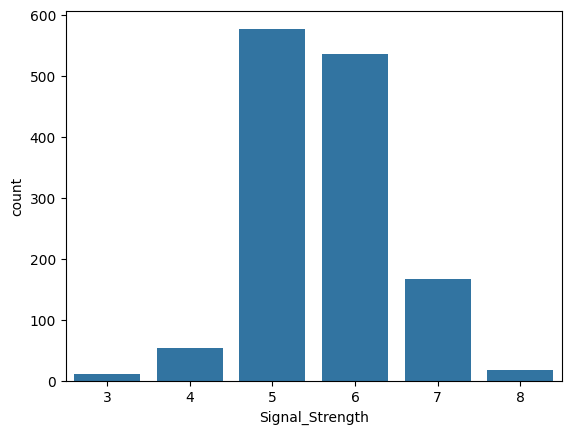

```python
# count plot on single numerical variable
sns.countplot(x ='Signal_Strength', data = signal_df)

# Show the plot
plt.show()
```

Distplot

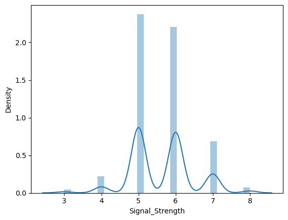

```python
sns.distplot(signal_df["Signal_Strength"]);
```

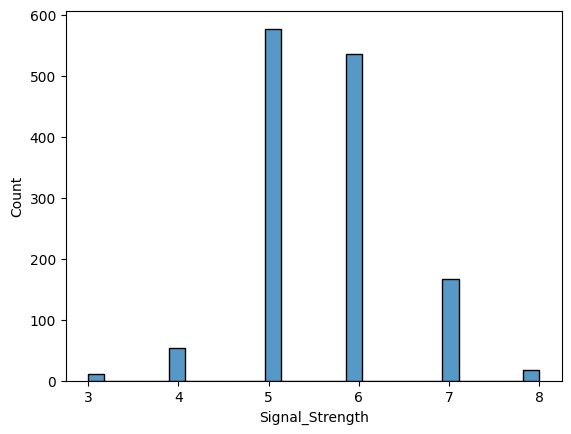

```python
sns.histplot(signal_df["Signal_Strength"]);
```

The maximum count (around 577) is for Signal_Strength = 5, followed by Signal_Strength = 6 (around 535).

```python
signal_df['Signal_Strength'].value_counts()
```

```
5    577
6    535
7    167
4     53
8     17
3     10
Name: Signal_Strength, dtype: int64
```

Bivariate Analysis

Finding the correlation of the various parameters.

```python
signal_df.corr()
```

|  | Parameter 1 | Parameter 2 | Parameter 3 | Parameter 4 | Parameter 5 | Parameter 6 | Parameter 7 | Parameter 8 | Parameter 9 | Parameter 10 | Parameter 11 | Signal_Strength |
| --- | --- | --- | --- | --- | --- | --- | --- | --- | --- | --- | --- | --- |
| Parameter 1 | 1.000000 | -0.255124 | 0.667437 | 0.111025 | 0.085886 | -0.140580 | -0.103777 | 0.670195 | -0.686685 | 0.190269 | -0.061596 | 0.119024 |
| Parameter 2 | -0.255124 | 1.000000 | -0.551248 | -0.002449 | 0.055154 | -0.020945 | 0.071701 | 0.023943 | 0.247111 | -0.256948 | -0.197812 | -0.395214 |
| Parameter 3 | 0.667437 | -0.551248 | 1.000000 | 0.143892 | 0.210195 | -0.048004 | 0.047358 | 0.357962 | -0.550310 | 0.326062 | 0.105108 | 0.228057 |
| Parameter 4 | 0.111025 | -0.002449 | 0.143892 | 1.000000 | 0.026656 | 0.160527 | 0.201038 | 0.324522 | -0.083143 | -0.011837 | 0.063281 | 0.013640 |
| Parameter 5 | 0.085886 | 0.055154 | 0.210195 | 0.026656 | 1.000000 | 0.000749 | 0.045773 | 0.193592 | -0.270893 | 0.394557 | -0.223824 | -0.130988 |
| Parameter 6 | -0.140580 | -0.020945 | -0.048004 | 0.160527 | 0.000749 | 1.000000 | 0.667246 | -0.018071 | 0.056631 | 0.054126 | -0.080125 | -0.050463 |
| Parameter 7 | -0.103777 | 0.071701 | 0.047358 | 0.201038 | 0.045773 | 0.667246 | 1.000000 | 0.078141 | -0.079257 | 0.035291 | -0.217829 | -0.177855 |
| Parameter 8 | 0.670195 | 0.023943 | 0.357962 | 0.324522 | 0.193592 | -0.018071 | 0.078141 | 1.000000 | -0.355617 | 0.146036 | -0.504995 | -0.184252 |
| Parameter 9 | -0.686685 | 0.247111 | -0.550310 | -0.083143 | -0.270893 | 0.056631 | -0.079257 | -0.355617 | 1.000000 | -0.214134 | 0.213418 | -0.055245 |
| Parameter 10 | 0.190269 | -0.256948 | 0.326062 | -0.011837 | 0.394557 | 0.054126 | 0.035291 | 0.146036 | -0.214134 | 1.000000 | 0.091621 | 0.248835 |
| Parameter 11 | -0.061596 | -0.197812 | 0.105108 | 0.063281 | -0.223824 | -0.080125 | -0.217829 | -0.504995 | 0.213418 | 0.091621 | 1.000000 | 0.480343 |
| Signal_Strength | 0.119024 | -0.395214 | 0.228057 | 0.013640 | -0.130988 | -0.050463 | -0.177855 | -0.184252 | -0.055245 | 0.248835 | 0.480343 | 1.000000 |

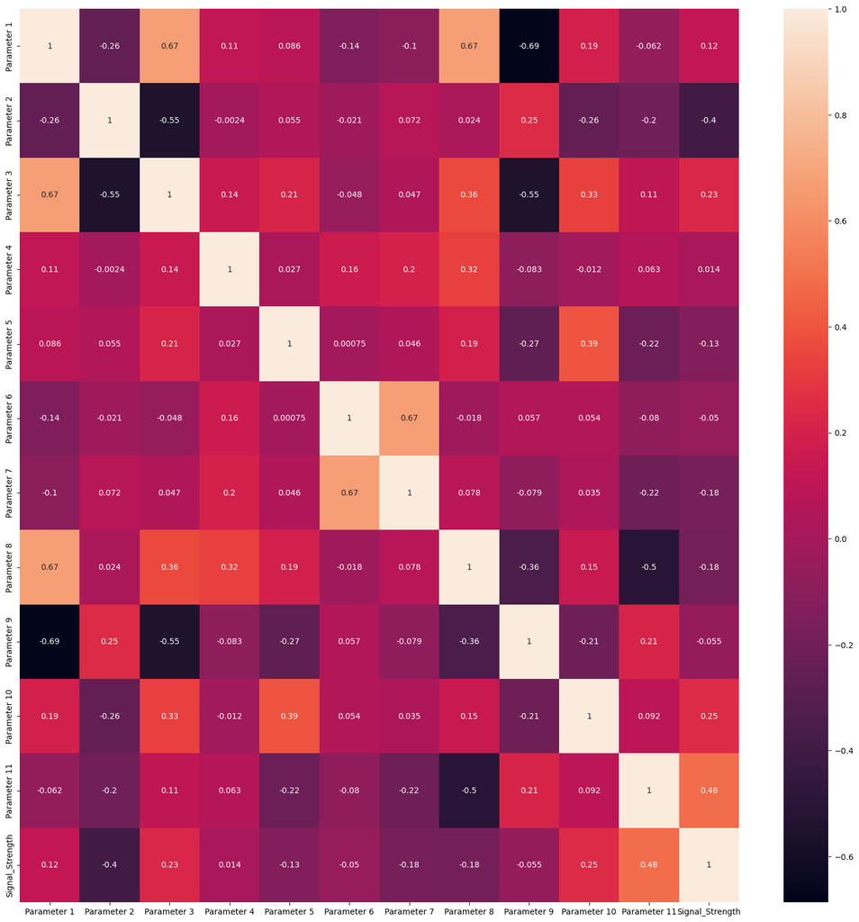

```python
fig, ax = plt.subplots(figsize=(20,20))         # Sample figsize in inches
ax = sns.heatmap(signal_df.corr(),annot=True);
```

We want to know about the various variables that have strong positive correlation between them, hence trying to find out the columns that have a correlation > 0.7

```python
signal_df.corr()[signal_df.corr()>0.7]
```

|  | Parameter 1 | Parameter 2 | Parameter 3 | Parameter 4 | Parameter 5 | Parameter 6 | Parameter 7 | Parameter 8 | Parameter 9 | Parameter 10 | Parameter 11 | Signal_Strength |
| --- | --- | --- | --- | --- | --- | --- | --- | --- | --- | --- | --- | --- |
| Parameter 1 | 1.0 | NaN | NaN | NaN | NaN | NaN | NaN | NaN | NaN | NaN | NaN | NaN |
| Parameter 2 | NaN | 1.0 | NaN | NaN | NaN | NaN | NaN | NaN | NaN | NaN | NaN | NaN |
| Parameter 3 | NaN | NaN | 1.0 | NaN | NaN | NaN | NaN | NaN | NaN | NaN | NaN | NaN |
| Parameter 4 | NaN | NaN | NaN | 1.0 | NaN | NaN | NaN | NaN | NaN | NaN | NaN | NaN |
| Parameter 5 | NaN | NaN | NaN | NaN | 1.0 | NaN | NaN | NaN | NaN | NaN | NaN | NaN |
| Parameter 6 | NaN | NaN | NaN | NaN | NaN | 1.0 | NaN | NaN | NaN | NaN | NaN | NaN |
| Parameter 7 | NaN | NaN | NaN | NaN | NaN | NaN | 1.0 | NaN | NaN | NaN | NaN | NaN |
| Parameter 8 | NaN | NaN | NaN | NaN | NaN | NaN | NaN | 1.0 | NaN | NaN | NaN | NaN |
| Parameter 9 | NaN | NaN | NaN | NaN | NaN | NaN | NaN | NaN | 1.0 | NaN | NaN | NaN |
| Parameter 10 | NaN | NaN | NaN | NaN | NaN | NaN | NaN | NaN | NaN | 1.0 | NaN | NaN |
| Parameter 11 | NaN | NaN | NaN | NaN | NaN | NaN | NaN | NaN | NaN | NaN | 1.0 | NaN |
| Signal_Strength | NaN | NaN | NaN | NaN | NaN | NaN | NaN | NaN | NaN | NaN | NaN | 1.0 |

None of the fields are strongly positively correlated.

We want to know about the various variables that have strong negative correlation between them, hence trying to find out the columns that have a correlation around -0.8.

```python
signal_df.corr()[signal_df.corr()<-0.8]
```

|  | Parameter 1 | Parameter 2 | Parameter 3 | Parameter 4 | Parameter 5 | Parameter 6 | Parameter 7 | Parameter 8 | Parameter 9 | Parameter 10 | Parameter 11 | Signal_Strength |
| --- | --- | --- | --- | --- | --- | --- | --- | --- | --- | --- | --- | --- |
| Parameter 1 | NaN | NaN | NaN | NaN | NaN | NaN | NaN | NaN | NaN | NaN | NaN | NaN |
| Parameter 2 | NaN | NaN | NaN | NaN | NaN | NaN | NaN | NaN | NaN | NaN | NaN | NaN |
| Parameter 3 | NaN | NaN | NaN | NaN | NaN | NaN | NaN | NaN | NaN | NaN | NaN | NaN |
| Parameter 4 | NaN | NaN | NaN | NaN | NaN | NaN | NaN | NaN | NaN | NaN | NaN | NaN |
| Parameter 5 | NaN | NaN | NaN | NaN | NaN | NaN | NaN | NaN | NaN | NaN | NaN | NaN |
| Parameter 6 | NaN | NaN | NaN | NaN | NaN | NaN | NaN | NaN | NaN | NaN | NaN | NaN |
| Parameter 7 | NaN | NaN | NaN | NaN | NaN | NaN | NaN | NaN | NaN | NaN | NaN | NaN |
| Parameter 8 | NaN | NaN | NaN | NaN | NaN | NaN | NaN | NaN | NaN | NaN | NaN | NaN |
| Parameter 9 | NaN | NaN | NaN | NaN | NaN | NaN | NaN | NaN | NaN | NaN | NaN | NaN |
| Parameter 10 | NaN | NaN | NaN | NaN | NaN | NaN | NaN | NaN | NaN | NaN | NaN | NaN |
| Parameter 11 | NaN | NaN | NaN | NaN | NaN | NaN | NaN | NaN | NaN | NaN | NaN | NaN |
| Signal_Strength | NaN | NaN | NaN | NaN | NaN | NaN | NaN | NaN | NaN | NaN | NaN | NaN |

None of the fields are strongly negatively correlated.

```python
# Correlation of all numerical variables (float) - 'Parameter 1','Parameter 2','Parameter 3','Parameter 4','Parameter 5','Parameter 6',
# 'Parameter 7','Parameter 8', 'Parameter 9', 'Parameter 10', 'Parameter 11' with the variable 'Signal_Strength'
corr1=signal_df['Parameter 1'].corr(signal_df['Signal_Strength'])
print("Parameter 1 and Signal_Strength corr is ",corr1)

corr2 = signal_df['Parameter 2'].corr(signal_df['Signal_Strength'])
print("Parameter 2 and Signal_Strength corr is ",corr2)

corr3 = signal_df['Parameter 3'].corr(signal_df['Signal_Strength'])
print("Parameter 3 and Signal_Strength corr is ",corr3)

corr4 = signal_df['Parameter 4'].corr(signal_df['Signal_Strength'])
print("Parameter 4 and Signal_Strength corr is ",corr4)

corr5 = signal_df['Parameter 5'].corr(signal_df['Signal_Strength'])
print("Parameter 5 and Signal_Strength corr is ",corr5)

corr6 = signal_df['Parameter 6'].corr(signal_df['Signal_Strength'])
print("Parameter 6 and Signal_Strength corr is ",corr6)

corr7 = signal_df['Parameter 7'].corr(signal_df['Signal_Strength'])
print("Parameter 7 and Signal_Strength corr is ",corr7)

corr8 = signal_df['Parameter 8'].corr(signal_df['Signal_Strength'])
print("Parameter 8 and Signal_Strength corr is ",corr8)

corr9 = signal_df['Parameter 9'].corr(signal_df['Signal_Strength'])
print("Parameter 9 and Signal_Strength corr is ",corr9)

corr10 = signal_df['Parameter 10'].corr(signal_df['Signal_Strength'])
print("Parameter 10 and Signal_Strength corr is ",corr10)

corr11 = signal_df['Parameter 11'].corr(signal_df['Signal_Strength'])
print("Parameter 11 and Signal_Strength corr is ",corr11)
```

```
Parameter 1 and Signal_Strength corr is  0.1190236656134977
Parameter 2 and Signal_Strength corr is  -0.3952136890098405
Parameter 3 and Signal_Strength corr is  0.22805745919929968
Parameter 4 and Signal_Strength corr is  0.013640470048445876
Parameter 5 and Signal_Strength corr is  -0.13098841286642668
Parameter 6 and Signal_Strength corr is  -0.050462766805025774
Parameter 7 and Signal_Strength corr is  -0.17785536568029603
Parameter 8 and Signal_Strength corr is  -0.18425165011902409
Parameter 9 and Signal_Strength corr is  -0.05524511495867183
Parameter 10 and Signal_Strength corr is  0.2488351355778882
Parameter 11 and Signal_Strength corr is  0.4803428980015536
```

Parameter 11 has the maximum positive correlation (0.48) with the dependent variable Signal_Strength, followed by Parameter 10 (0.25).

Pair Plot

```python
sns.pairplot(signal_df,diag_kind="kde")
```

```
Output hidden; open in https://colab.research.google.com to view.
```

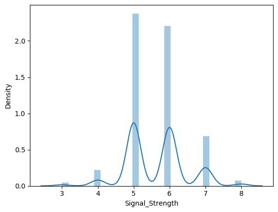

```
Distribution of target variable- Signal_Strength
The mean is  5.6232523914643116
The median is  6.0
The mode is  5
The minimum value is  3
The maximum value is  8
The standard deviation is  0.8235780017165553
The skewness is  0.19240658731658308
```

```python
# Visualize the distribution of target variable
sns.distplot(signal_df['Signal_Strength'])
plt.show()
print('Distribution of target variable- Signal_Strength')

print('The mean is ',signal_df['Signal_Strength'].mean())
print('The median is ',signal_df['Signal_Strength'].median())
print('The mode is ',signal_df['Signal_Strength'].mode()[0])

print('The minimum value is ',signal_df['Signal_Strength'].min())
print('The maximum value is ',signal_df['Signal_Strength'].max())

print('The standard deviation is ',signal_df['Signal_Strength'].std())
print('The skewness is ',signal_df['Signal_Strength'].skew())
```

The skewness is around 0.192 for the target variable. Hence, the distribution is approximately symmetric.

```python
print(signal_df.columns)
```

```
Index(['Parameter 1', 'Parameter 2', 'Parameter 3', 'Parameter 4',
       'Parameter 5', 'Parameter 6', 'Parameter 7', 'Parameter 8',
       'Parameter 9', 'Parameter 10', 'Parameter 11', 'Signal_Strength'],
      dtype='object')
```

Check for outliers

```python
numeric_columns = signal_df.select_dtypes(['int','float']).columns
numeric_columns
```

```
Index(['Parameter 1', 'Parameter 2', 'Parameter 3', 'Parameter 4',
       'Parameter 5', 'Parameter 6', 'Parameter 7', 'Parameter 8',
       'Parameter 9', 'Parameter 10', 'Parameter 11', 'Signal_Strength'],
      dtype='object')
```

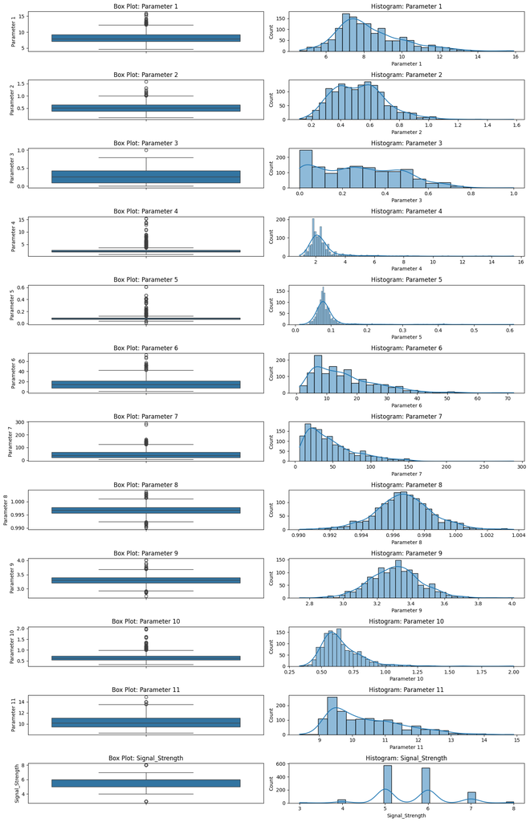

```python
plt.figure(figsize=(15,40))
c = 1
for i in numeric_columns:
    plt.subplot(21,2,c)
    sns.boxplot(data=signal_df, y=i)
    plt.title(f'Box Plot: {i}')
    plt.subplot(21,2,c+1)
    sns.histplot(data=signal_df, x=i, kde=True)
    plt.title(f'Histogram: {i}')
    c += 2

plt.tight_layout();
```

All the fields here have outliers. Hence, outlier treatment needs to be done here. Outliers not only hamper data quality but also affect the output in case of prediction models. Prediction tools like Neural Networks (NN) need outlier free dataset in order to achieve better generalization of the network, as errors in the dataset hinder the modelling process and produce misleading results.

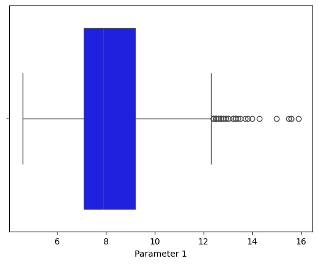

```
Boxplot of  Parameter 1
Q1 is :  7.1
Q2 is :  7.9
Q3 is :  9.2
IQR is: 2.0999999999999996
Lower Whisker, Upper Whisker :  3.95 , 12.349999999999998
Out of  1359  rows in data, number of outliers are: 41
```

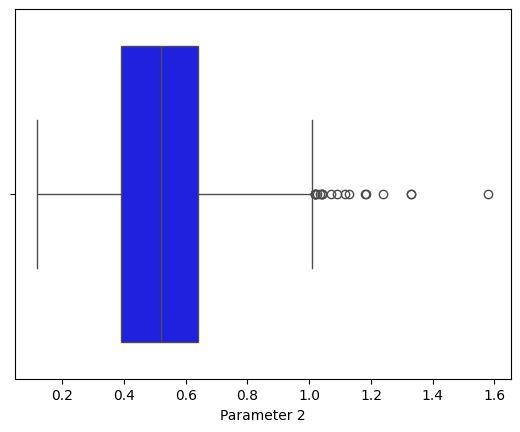

```
Boxplot of  Parameter 2
Q1 is :  0.39
Q2 is :  0.52
Q3 is :  0.64
IQR is: 0.25
Lower Whisker, Upper Whisker :  0.015000000000000013 , 1.0150000000000001
Out of  1359  rows in data, number of outliers are: 19
```

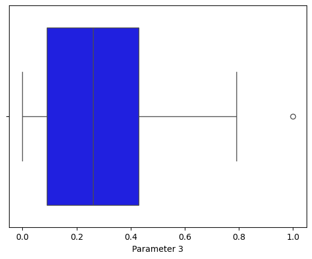

```
Boxplot of  Parameter 3
Q1 is :  0.09
Q2 is :  0.26
Q3 is :  0.43
IQR is: 0.33999999999999997
Lower Whisker, Upper Whisker :  -0.42000000000000004 , 0.94
Out of  1359  rows in data, number of outliers are: 1
```

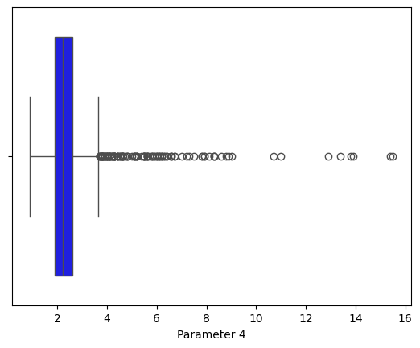

```
Boxplot of  Parameter 4
Q1 is :  1.9
Q2 is :  2.2
Q3 is :  2.6
IQR is: 0.7000000000000002
Lower Whisker, Upper Whisker :  0.8499999999999996 , 3.6500000000000004
Out of  1359  rows in data, number of outliers are: 126
```

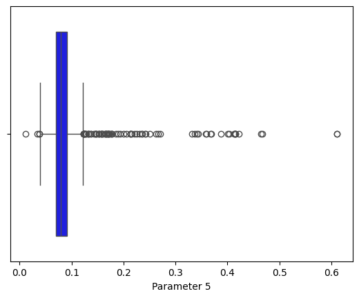

```
Boxplot of  Parameter 5
Q1 is :  0.07
Q2 is :  0.079
Q3 is :  0.091
IQR is: 0.02099999999999999
Lower Whisker, Upper Whisker :  0.03850000000000002 , 0.12249999999999998
Out of  1359  rows in data, number of outliers are: 87
```

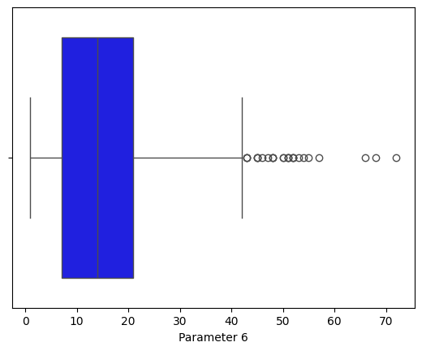

```
Boxplot of  Parameter 6
Q1 is :  7.0
Q2 is :  14.0
Q3 is :  21.0
IQR is: 14.0
Lower Whisker, Upper Whisker :  -14.0 , 42.0
Out of  1359  rows in data, number of outliers are: 26
```

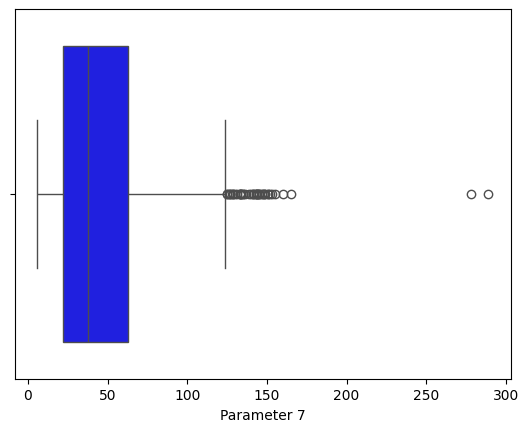

```
Boxplot of  Parameter 7
Q1 is :  22.0
Q2 is :  38.0
Q3 is :  63.0
IQR is: 41.0
Lower Whisker, Upper Whisker :  -39.5 , 124.5
Out of  1359  rows in data, number of outliers are: 45
```

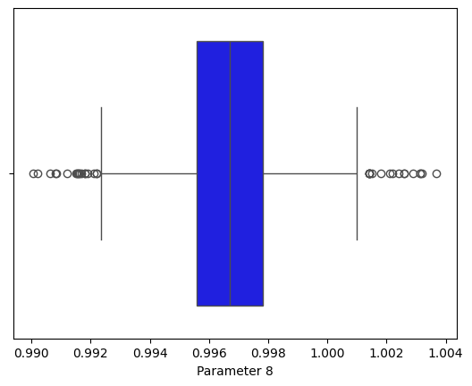

```
Boxplot of  Parameter 8
Q1 is :  0.9956
Q2 is :  0.9967
Q3 is :  0.99782
IQR is: 0.0022199999999999998
Lower Whisker, Upper Whisker :  0.99227 , 1.00115
Out of  1359  rows in data, number of outliers are: 35
```

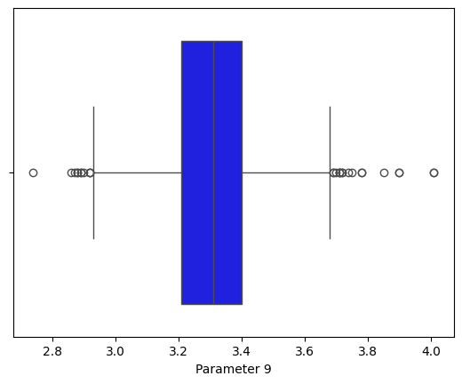

```
Boxplot of  Parameter 9
Q1 is :  3.21
Q2 is :  3.31
Q3 is :  3.4
IQR is: 0.18999999999999995
Lower Whisker, Upper Whisker :  2.925 , 3.6849999999999996
Out of  1359  rows in data, number of outliers are: 28
```

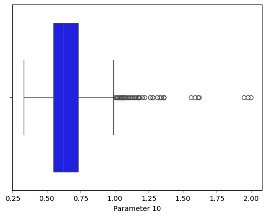

```
Boxplot of  Parameter 10
Q1 is :  0.55
Q2 is :  0.62
Q3 is :  0.73
IQR is: 0.17999999999999994
Lower Whisker, Upper Whisker :  0.28000000000000014 , 0.9999999999999999
Out of  1359  rows in data, number of outliers are: 55
```

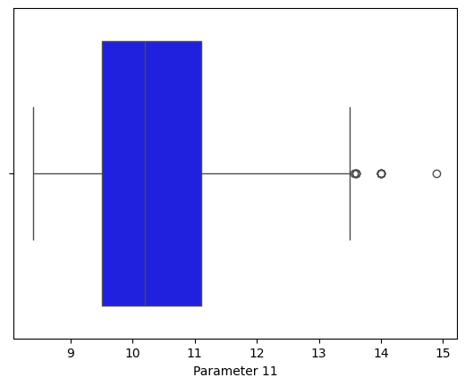

```
Boxplot of  Parameter 11
Q1 is :  9.5
Q2 is :  10.2
Q3 is :  11.1
IQR is: 1.5999999999999996
Lower Whisker, Upper Whisker :  7.1000000000000005 , 13.5
Out of  1359  rows in data, number of outliers are: 12
```

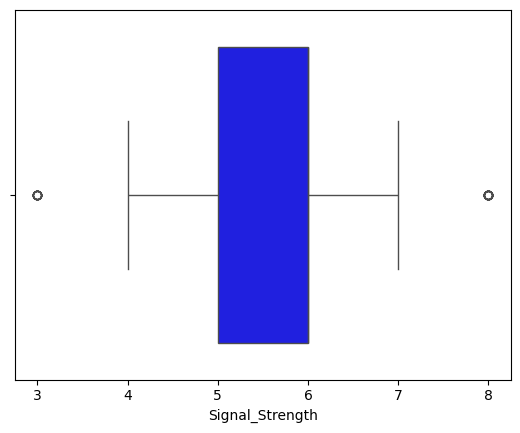

```
Boxplot of  Signal_Strength
Q1 is :  5.0
Q2 is :  6.0
Q3 is :  6.0
IQR is: 1.0
Lower Whisker, Upper Whisker :  3.5 , 7.5
Out of  1359  rows in data, number of outliers are: 27
```

```python
# Checking whether outliers are present or not
l = len(signal_df)
col = list(signal_df.columns)
#col.remove('condition')
for i in np.arange(len(col)):
    sns.boxplot(x= signal_df[col[i]], color='blue')
    plt.show()
    print('Boxplot of ',col[i])
    #calculating the outiers in attribute
    Q1 = signal_df[col[i]].quantile(0.25)
    Q2 = signal_df[col[i]].quantile(0.50)
    Q3 = signal_df[col[i]].quantile(0.75)
    IQR = Q3 - Q1
    L_W = (Q1 - 1.5 *IQR)
    U_W = (Q3 + 1.5 *IQR)
    print('Q1 is : ',Q1)
    print('Q2 is : ',Q2)
    print('Q3 is : ',Q3)
    print('IQR is:',IQR)
    print('Lower Whisker, Upper Whisker : ',L_W,',',U_W)
    bools = (signal_df[col[i]] < (Q1 - 1.5 *IQR)) |(signal_df[col[i]] > (Q3 + 1.5 * IQR))
    print('Out of ',l,' rows in data, number of outliers are:',bools.sum())   #calculating the number of outliers
```

Parameters have the following number of outliers.

1. Parameter 1 : 41
2. Parameter 2 : 19
3. Parameter 3 : 1
4. Parameter 4 : 126
5. Parameter 5 : 87
6. Parameter 6 : 26
7. Parameter 7 : 45
8. Parameter 8 : 35
9. Parameter 9 : 28
10. Parameter 10 : 55
11. Parameter 11 : 12
12. Signal_Strength : 27

Parameter 4 has the maximum outliers (around 126).

Outlier Treatment

```python
#  function to treat outliers
def detect_treate_outliers(df,operation):
    cols=[]
    IQR_list=[]
    lower_boundary_list=[]
    upper_boundary_list=[]
    outliers_count=[]
    for col in df.columns:
        #print('col',col)
        if((df[col].dtype =='int64' or df[col].dtype =='float64') and (col != 'HR')):
            #print('Inside if')
            IQR = df[col].quantile(0.75) - df[col].quantile(0.25)
            lower_boundary = df[col].quantile(0.25) - (1.5 * IQR)
            upper_boundary = df[col].quantile(0.75) + (1.5 * IQR)
            up_cnt = df[df[col]>upper_boundary][col].shape[0]
            #print('Upper count=',up_cnt)
            lw_cnt = df[df[col]<lower_boundary][col].shape[0]
            #print('lower count=',lw_cnt)
            if(up_cnt+lw_cnt) > 0:
                cols.append(col)
                IQR_list.append(IQR)
                lower_boundary_list.append(lower_boundary)
                upper_boundary_list.append(upper_boundary)
                outliers_count.append(up_cnt+lw_cnt)
                if operation == 'update':
                    df.loc[df[col] > upper_boundary,col] = upper_boundary
                    df.loc[df[col] < lower_boundary,col] = lower_boundary
                else:
                    pass
            else:
                pass
   #print('cols=',cols)
   # print('IQR_list=',IQR_list)
   # print('lower_boundary_list=',lower_boundary_list)
   # print('upper_boundary_list=',upper_boundary_list)
   # print('outliers_count=',outliers_count)
    ndf = pd.DataFrame(list(zip(cols,IQR_list,lower_boundary_list,upper_boundary_list,outliers_count)),columns=['Features','IQR','Lower Boundary','Upper Boundary','Outlier Count'])
    #print('Data=',ndf)
    #print('Columns having outliers=',cols)
    if operation == 'update':
        return (len(cols),df)
    else:
        return (len(cols),ndf)
```

```python
#Removing outliers by replacing the data below lower whisker with it and above upper whisker with it respectively.
count,df=detect_treate_outliers(signal_df,'update')
if count>0:
    print('Updating dataset')
    signal_df=df
```

```
Updating dataset
```

Checking the outliers after outlier treatment

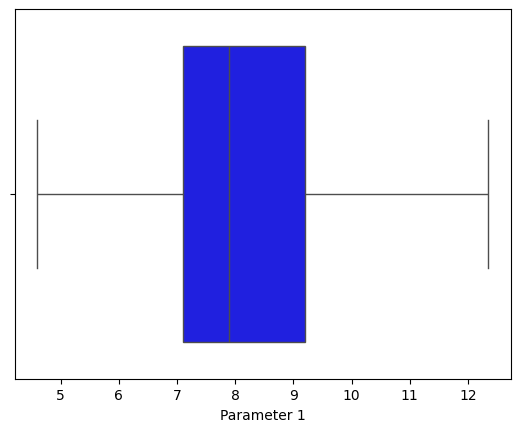

```
Boxplot of  Parameter 1
Q1 is :  7.1
Q2 is :  7.9
Q3 is :  9.2
IQR is: 2.0999999999999996
Lower Whisker, Upper Whisker :  3.95 , 12.349999999999998
Out of  1359  rows in data, number of outliers are: 0
```

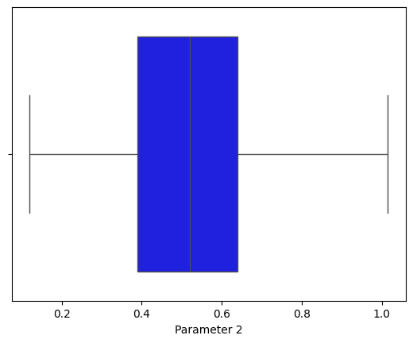

```
Boxplot of  Parameter 2
Q1 is :  0.39
Q2 is :  0.52
Q3 is :  0.64
IQR is: 0.25
Lower Whisker, Upper Whisker :  0.015000000000000013 , 1.0150000000000001
Out of  1359  rows in data, number of outliers are: 0
```

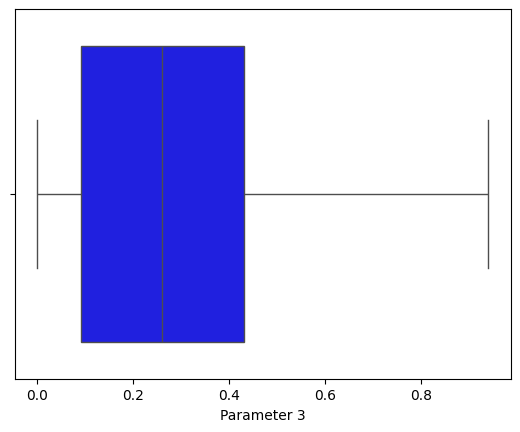

```
Boxplot of  Parameter 3
Q1 is :  0.09
Q2 is :  0.26
Q3 is :  0.43
IQR is: 0.33999999999999997
Lower Whisker, Upper Whisker :  -0.42000000000000004 , 0.94
Out of  1359  rows in data, number of outliers are: 0
```

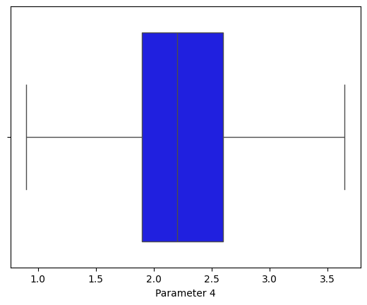

```
Boxplot of  Parameter 4
Q1 is :  1.9
Q2 is :  2.2
Q3 is :  2.6
IQR is: 0.7000000000000002
Lower Whisker, Upper Whisker :  0.8499999999999996 , 3.6500000000000004
Out of  1359  rows in data, number of outliers are: 0
```

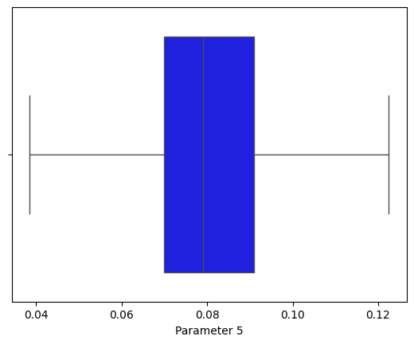

```
Boxplot of  Parameter 5
Q1 is :  0.07
Q2 is :  0.079
Q3 is :  0.091
IQR is: 0.02099999999999999
Lower Whisker, Upper Whisker :  0.03850000000000002 , 0.12249999999999998
Out of  1359  rows in data, number of outliers are: 0
```

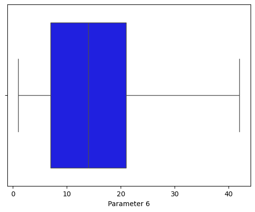

```
Boxplot of  Parameter 6
Q1 is :  7.0
Q2 is :  14.0
Q3 is :  21.0
IQR is: 14.0
Lower Whisker, Upper Whisker :  -14.0 , 42.0
Out of  1359  rows in data, number of outliers are: 0
```

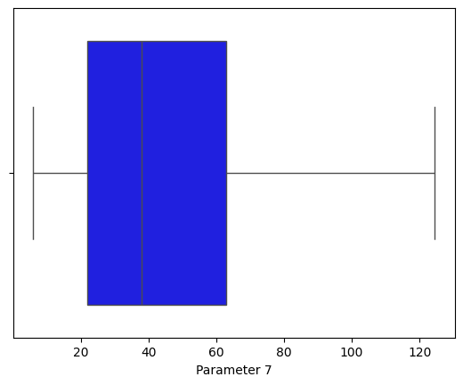

```
Boxplot of  Parameter 7
Q1 is :  22.0
Q2 is :  38.0
Q3 is :  63.0
IQR is: 41.0
Lower Whisker, Upper Whisker :  -39.5 , 124.5
Out of  1359  rows in data, number of outliers are: 0
```

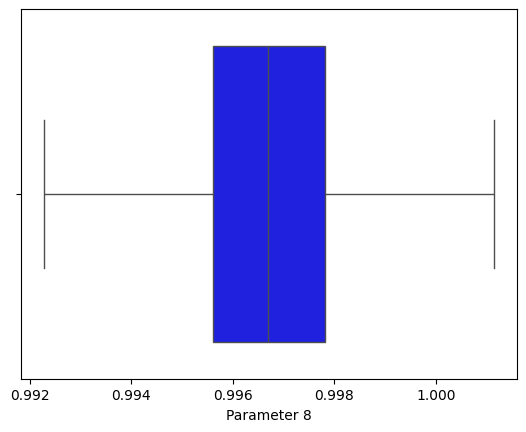

```
Boxplot of  Parameter 8
Q1 is :  0.9956
Q2 is :  0.9967
Q3 is :  0.99782
IQR is: 0.0022199999999999998
Lower Whisker, Upper Whisker :  0.99227 , 1.00115
Out of  1359  rows in data, number of outliers are: 0
```

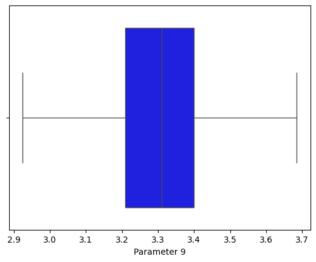

```
Boxplot of  Parameter 9
Q1 is :  3.21
Q2 is :  3.31
Q3 is :  3.4
IQR is: 0.18999999999999995
Lower Whisker, Upper Whisker :  2.925 , 3.6849999999999996
Out of  1359  rows in data, number of outliers are: 0
```

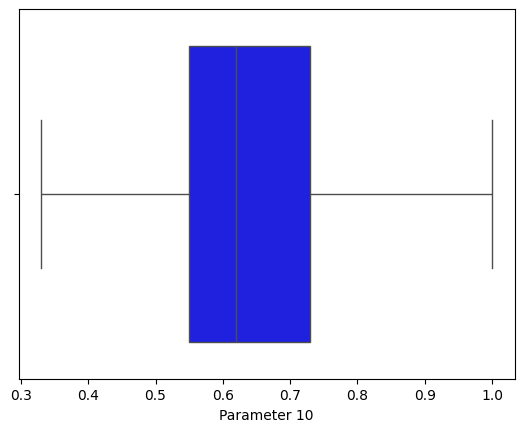

```
Boxplot of  Parameter 10
Q1 is :  0.55
Q2 is :  0.62
Q3 is :  0.73
IQR is: 0.17999999999999994
Lower Whisker, Upper Whisker :  0.28000000000000014 , 0.9999999999999999
Out of  1359  rows in data, number of outliers are: 0
```

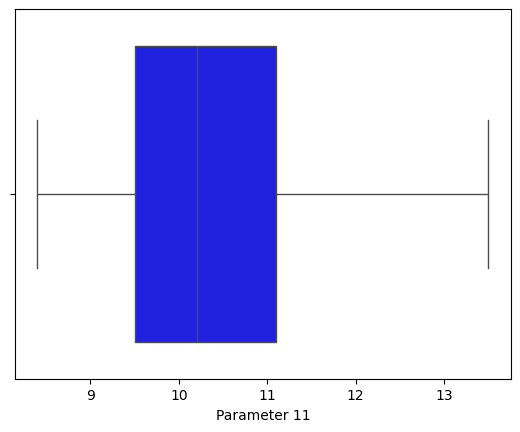

```
Boxplot of  Parameter 11
Q1 is :  9.5
Q2 is :  10.2
Q3 is :  11.1
IQR is: 1.5999999999999996
Lower Whisker, Upper Whisker :  7.1000000000000005 , 13.5
Out of  1359  rows in data, number of outliers are: 0
```

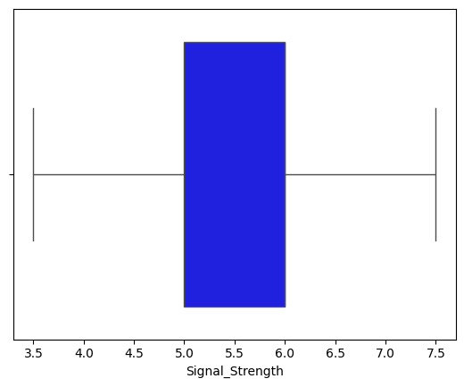

```
Boxplot of  Signal_Strength
Q1 is :  5.0
Q2 is :  6.0
Q3 is :  6.0
IQR is: 1.0
Lower Whisker, Upper Whisker :  3.5 , 7.5
Out of  1359  rows in data, number of outliers are: 0
```

```python
# Checking the status of outliers after treatment
l = len(signal_df)
col = list(signal_df.columns)
#col.remove('condition')
for i in np.arange(len(col)):
    sns.boxplot(x= signal_df[col[i]], color='blue')
    plt.show()
    print('Boxplot of ',col[i])
    #calculating the outiers in attribute
    Q1 = signal_df[col[i]].quantile(0.25)
    Q2 = signal_df[col[i]].quantile(0.50)
    Q3 = signal_df[col[i]].quantile(0.75)
    IQR = Q3 - Q1
    L_W = (Q1 - 1.5 *IQR)
    U_W = (Q3 + 1.5 *IQR)
    print('Q1 is : ',Q1)
    print('Q2 is : ',Q2)
    print('Q3 is : ',Q3)
    print('IQR is:',IQR)
    print('Lower Whisker, Upper Whisker : ',L_W,',',U_W)
    bools = (signal_df[col[i]] < (Q1 - 1.5 *IQR)) |(signal_df[col[i]] > (Q3 + 1.5 * IQR))
    print('Out of ',l,' rows in data, number of outliers are:',bools.sum())   #calculating the number of outliers
```

Outliers increase the variability in your data, which decreases statistical power. Consequently, excluding outliers can cause your results to become statistically significant. As the outliers have been removed, further checking the correlation between the attributes.

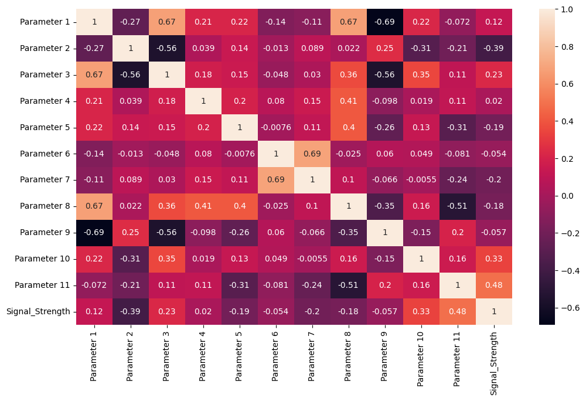

```python
# Analyzing correlation between the attributes, after removal of outliers.
b_corr=signal_df.corr()
plt.subplots(figsize =(12, 7))
sns.heatmap(b_corr,annot=True)
```

The strong correlation values lie between ± 0.50 and ± 1.

1. Parameter 1 is strongly positively correlated with Parameter 3 (0.67).
2. Parameter 1 is strongly positively correlated with Parameter 8 (0.67).
3. Parameter 1 is strongly negatively correlated with Parameter 9 (-0.69).
4. Parameter 6 is strongly positively correlated with Parameter 7 (0.69).

The parameters are not highly correlated i.e. 0.8 or above. Hence, the features are not eliminated here. Multicollinearity is not a problem in Neural Networks. The main reason for that is that multicollinearity is an issue which only arises, when we have linear relationships. Neural Networks with more than 1 hidden layer already does not qualify for this case.

Check the feature importance of the given attributes.

```python
!pip install scikit-learn
```

```python
from sklearn.ensemble import ExtraTreesClassifier
# ExtraTreesClassifier class implements a meta estimator that fits
# a number of randomized decision trees (a.k.a. extra-trees) on various
# sub-samples of the dataset and uses averaging to improve the predictive
# accuracy and control over-fitting.
```

```python
from sklearn.tree import DecisionTreeClassifier
```

ExtraTreeClassifier is an extremely randomized version of DecisionTreeClassifier meant to be used internally as part of the ExtraTreesClassifier ensemble.

```python
# Feature Importance

# Independent variables
X=signal_df.drop('Signal_Strength',axis=1)

# Target variable
Y=signal_df['Signal_Strength']
```

```python
import matplotlib.pyplot as plt
# model = ExtraTreesClassifier()
# Change the classifier type
model = DecisionTreeClassifier()
```

The DecisionTreeClassifier model expects the target variable y to be a categorical variable.

Convert the target variable to a categorical variable:

```python
from sklearn.preprocessing import LabelEncoder

le = LabelEncoder()
Y = le.fit_transform(Y)
```

Print the type of the target variable Y

```python
print(type(Y))
```

```
<class 'numpy.ndarray'>
```

Investigate the values of the target variable:

```python
print(np.unique(Y))
```

```
[0 1 2 3 4 5]
```

```python
model.fit(X,Y)
# Model fitting is a measure of how well a machine learning model
# generalizes to similar data to that on which it was trained.
```

```
DecisionTreeClassifier()
```

```python
# using inbuilt class "feature_importances_" of tree based classifiers
# The impurity-based feature importances.The higher, the more important
# the feature. The importance of a feature is computed as the (normalized)
# total reduction of the criterion brought by that feature.
# It is also known as the Gini importance.
print(model.feature_importances_)
```

```
[0.06378222 0.11055095 0.06682896 0.05854921 0.07507856 0.058976
 0.12487841 0.07188258 0.07799367 0.1145372  0.17694224]
```

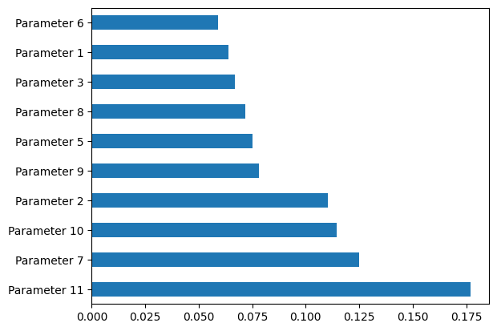

```python
#plotting graph of feature importances
ftre_imp = pd.Series(model.feature_importances_, index=X.columns)
ftre_imp.nlargest(10).plot(kind='barh')
plt.show()
```

Parameter 11 has the highest feature importance and hence, is the most relevant parameter.

Part A - Q1 E - Share insights from the initial data analysis (at least 2).

Insights from the initial data analysis:

a. Distribution of Signal Strength: According to the given dataset, the majority of the variable "Signal_Strength" is located between 5 and 6. For 'Signal_Strength' 5 and 6, the counts are 577 and 535, respectively, which is a far higher count. As a result, we note that the dataset exhibits an imbalance with a bias towards these particular values in the field "Signal_Strength."

b. Range and Variability of Parameters: The statistical analysis of the several variables (parameters 1 through 11) shows that the standard deviation and ranges of each vary. For instance, Parameter 7 in this dataset has a standard deviation of 32.90, which is rather high, whereas Parameter 6 has a standard deviation of 10.46. This suggests more variation in the data, which could therefore affect the estimation of signal strength. As a result, when training the model, we would need to be cautious with these values.

Parameter 11 has the maximum positive correlation (0.48) with the target variable Signal_Strength, followed by Parameter 10 (0.25).

Parameter 2 has the maximum negative correlation (-0.39) with the target variable Signal_Strength, followed by Parameter 8 (-0.18) and Parameter 7 (-0.17) respectively.

Distribution of target variable- Signal_Strength

1. Mean 5.620676968359088
2. Median 6.0
3. Mode 5.0
4. Minimum value 3.5
5. Maximum value 7.5
6. Standard Deviation 0.7963507421717632
7. Skewness 0.1771681345358897

If skewness is between -0.5 and 0.5, the distribution is approximately symmetric. Hence, the distribution is approximately symmetric for the target variable 'Signal_Strength'.

Part A - Q2 A - Split the data into X & Y.

```python
# to count the number of classes in output
signal_df['Signal_Strength'].value_counts()
```

```
5.0    577
6.0    535
7.0    167
4.0     53
7.5     17
3.5     10
Name: Signal_Strength, dtype: int64
```

```python
# Independent variables
X=signal_df.drop('Signal_Strength',axis=1)

# Target variable
Y=signal_df['Signal_Strength']
```

```python
X.shape
```

```
(1359, 11)
```

```python
Y.shape
```

```
(1359,)
```

```python
# Applying the function to convert field Y from numeric to categorical (one-hot encoding)
from keras.utils import to_categorical
YC = to_categorical(Y, num_classes=8)
```

Part A - Q2 B - Split the data into train & test with 70:30 proportion.

```python
# Split the data into train & test (categorical now) with 70:30 proportion.
from sklearn.model_selection import train_test_split
X_train, X_test, YC_train, YC_test = train_test_split(X, YC, test_size=.30, random_state=42)
# Random_state is used to set the seed for the random generator,
# so that we can ensure that the results that we get can be reproduced.
```

Part A - Q2 C - Print shape of all the 4 variables and verify if train and test data is in sync.

```python
print("Shape of X_train:", X_train.shape)
print("Shape of X_test :", X_test.shape)
```

```
Shape of X_train: (951, 11)
Shape of X_test : (408, 11)
```

```python
print("Shape of YC_train:", YC_train.shape)
print("Shape of YC_test :", YC_test.shape)
```

```
Shape of YC_train: (951, 8)
Shape of YC_test : (408, 8)
```

Part A - Q2 D - Normalise the train and test data with appropriate method.